# Exploratory Analysis

## Average Salary per Race Chart

The purpose of this chart is to allow us to see the average income per race in King County. In analyzing the statistics, we can conclude that Asians have the highest average income than Black folks.

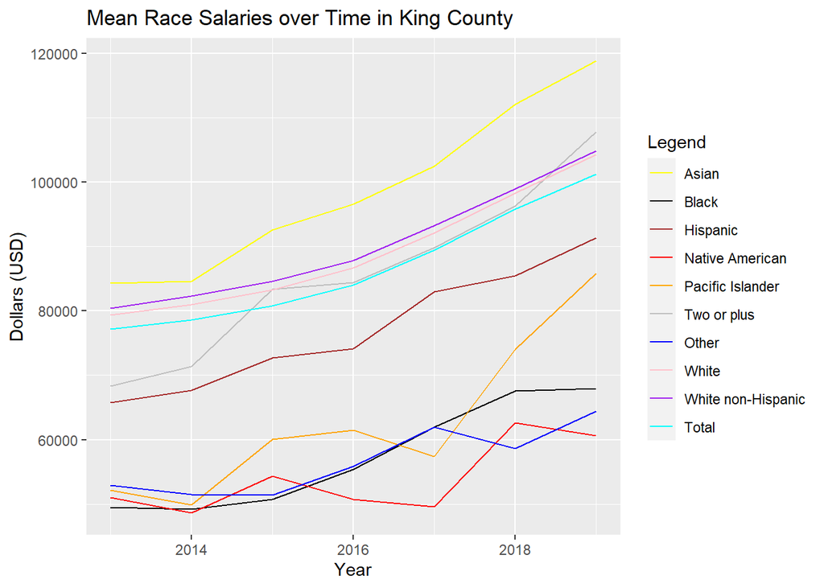

## Poverty by Race Chart

The purpose of this chart is to allow us to see the percentage of race population in poverty within the King County area. According to the Race Chart, we can see that white people have the highest percentage of poverty in comparison to BIPOC folx. While this may be the case, the dataset only shows the percentage of the total white population in poverty.

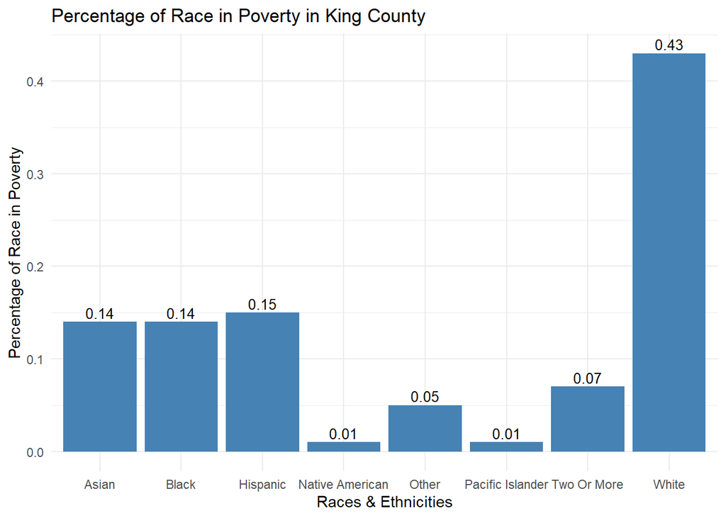

## Difference in Wage by Gender Chart

The purpose of this chart is to allow us to see the average wage for female and male workers from the same occupation. In analyzing the data, we can see that there is an income disparity and that male workers tend to get paid more by a significant amount.

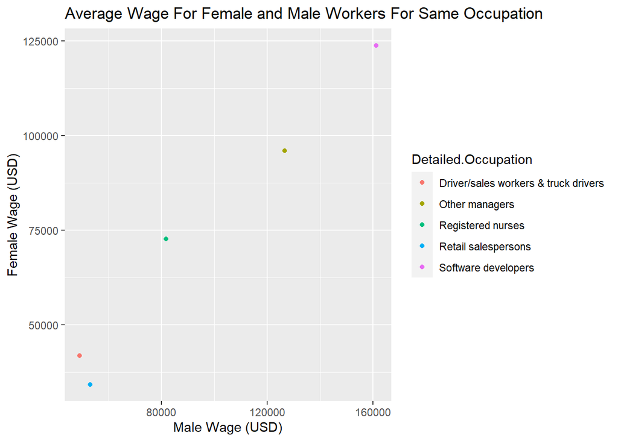